# COMPSCIX 415.2 Homework 6

## *Excercise 2*

The Central Limit Theorem states that the sampling distribution of sample means is approximately Normal, regardless of the distribution of your population. For this exercise our population distribution will be a Gamma(1,2) distribution, and we’ll show that the sampling distribution of the mean is in fact normally distributed.

### 1. Generate a random sample of size n = 10000 from a gamma(1,2) distribution and plot a histogram or density curve. Use the code below to help you get your sample.

```r
library(tidyverse)
n <- 10000
gamma_samp <- tibble(x = rgamma(n, shape = 1, scale = 2))
```

```r
?rgamma
```

### 2. What is the mean and standard deviation of your sample? They should both be close to 2 because for a gamma distribution:

mean = shape x scale variance = shape x scale^2

```r
mean_samp <- gamma_samp %>% .[['x']] %>% mean()
mean_samp
```

```
## [1] 2.013407
```

```r
sd_samp <- gamma_samp %>% .[['x']] %>% sd()
sd_samp
```

```
## [1] 2.027773
```

```r
gamma_samp %>% sample_n(30) %>%
  summarize(mean_x = mean(x, na.rm = TRUE),
            sd_x = sd(x, na.rm = TRUE))
```

```
## # A tibble: 1 x 2
##   mean_x  sd_x
##    <dbl> <dbl>
## 1   1.65  1.50
```

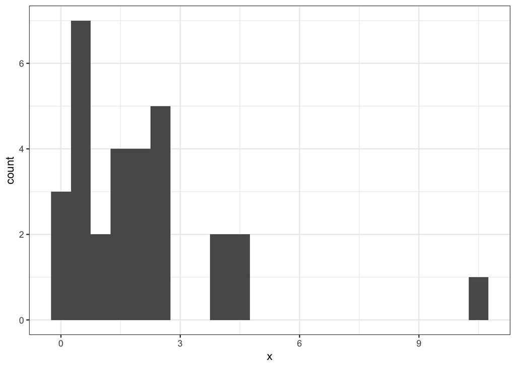

```r
gamma_samp %>% sample_n(30)%>% ggplot()+
    geom_histogram(aes(x = x), binwidth=0.5)+
    theme_bw()
```

### 4. Take a sample of size n = 30, again from the Gamma(1,2) distribution, calculate the mean, and assign it to a vector named mean_samp. Repeat this 10000 times!!!! The code below might help.

```r
# create a vector with 10000 NAs
mean_samp <- rep(NA, 10000)

# start a loop
for(i in 1:10000) {
  g_samp <- rgamma(30, shape = 1, scale = 2)
  mean_samp[i] <- mean(g_samp)
}
# Convert vector to a tibble
mean_samp <- tibble(mean_samp)
```